# Patterns in Terrorism Around the World

Jason Renn

6/4/2019

## What is Terrorism?

You may have encountered different definitions of terrorism, depending on your life experiences. One common historical claim is that

> One Man’s Terrorist is Another Man’s Freedom Fighter

This view highlights the issue of subjectivity in examining social phenomena. If it were true that terrorism depends on the view of the author, then it would be too easy for us to also justify a definition that was essentially, “terrorism is what my enemies do – not what I do.”

Even government institutions are hesitant to embrace this broad of a view of terrorism. Consider instead this definition where *Terrorism* is:

> “…the unlawful use of violence or threat of violence to instill fear and coerce governments or societies. Terrorism is often motivated by religious, political, or other ideological beliefs and committed in the pursuit of goals that are usually political.” (US Department of Defense)

## The Global Terrorism Database

In this data exploration, we will look at a dataset that seeks to systematically record information on terrorism. This source is not perfect, but it allows us to begin asking more questions besides the more philosophical “what is terrorism?”

Here are a few details about the dataset which should help you understand how to use it and if you should trust the data.

- The [Global Terrorism Database (GTD)](https://www.start.umd.edu/gtd/)[^1] housed at the University of Maryland
- Source for systematic information on the use of terrorism using event (news) data
- Several [critiques](https://www.washingtonpost.com/news/monkey-cage/wp/2014/08/11/how-to-fix-the-flaws-in-the-global-terrorism-database-and-why-it-matters/?utm_term=.6dcdcbc3e1b0) but it remains a key source in academic and policy research
- This slice of the data covers only 2004-2006

## Where Does it Happen?

One pattern that we’d like to examine is how terrorist activities spread throughout the world. Consider the following map, which depicts the location of terrorist activities between 2004-2006. We see that attacks are not evenly spread throughout the globe.

[interactive chart not shown]

## Terrorism Over Time

During this period, many governments in the West declared that instances of terrorism were on the rise. According to these data, it is. As such, leaders called for the build up of militaries to fight terrorism and for action in countries such as Iraq (2003) and Afghanistan (2001) that continue in some form to this day.

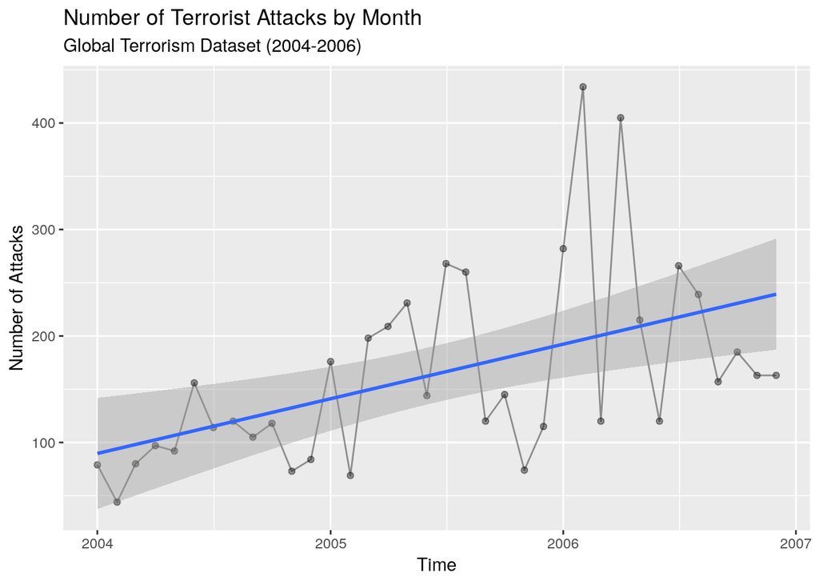

## Typically not Lethal

Even with the concern about the increase in the number of terrorist activities one should make sure to understand the risk associated with terrorism. Attacks are infrequent and rarely lethal.

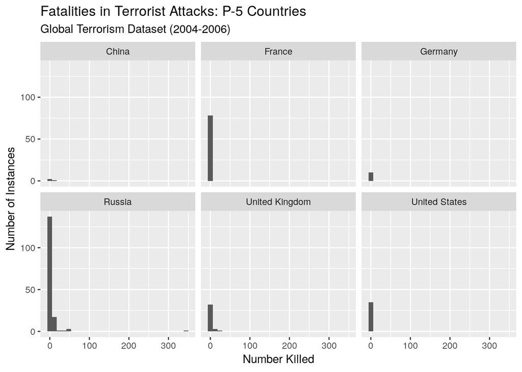

Attacks in countries suffering from other forms of violence (i.e. war) are much more likely to kill and maim.

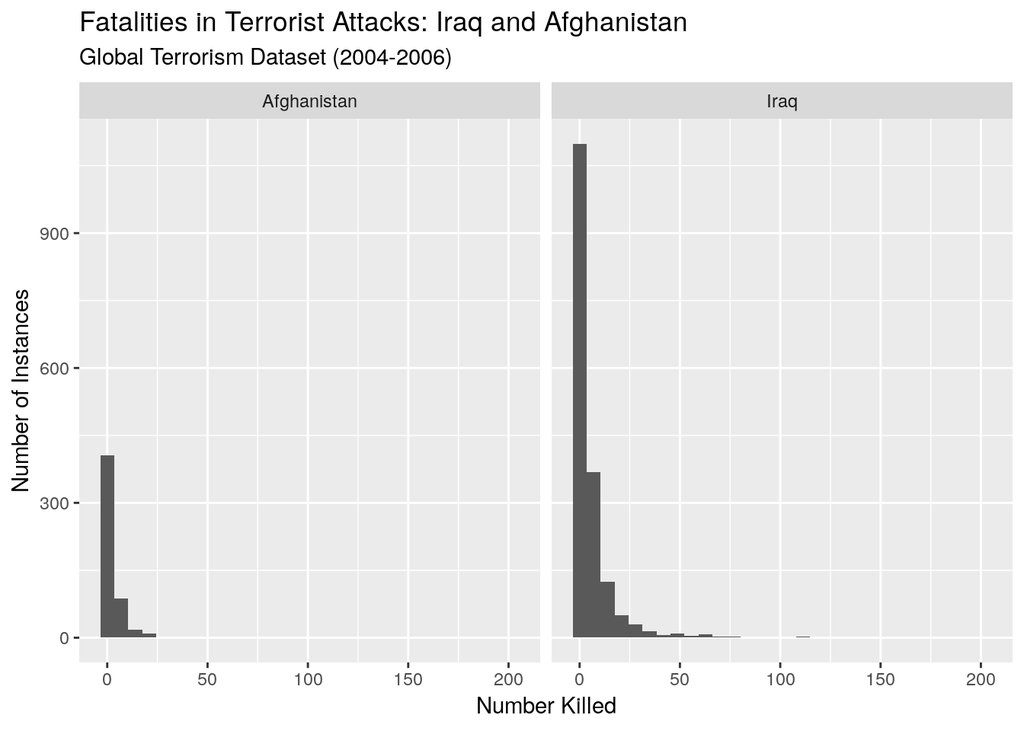

## Look at the Data

You can use the table below to read about the specific attacks and a brief description of the event.

|  | country_txt | date | scite1 | nkill |
| --- | --- | --- | --- | --- |
| 1 | Iraq | 2004-04-11 | "Three Czech hostages in Iraq freed and in good health," Agence France Presse, April 16, 2004. | 0 |
| 2 | India | 2004-01-01 | "One Killed, 20 injured in explosion in Indian Kashmir", Deutsche Presse-Agentur, January 1, 2004 | 1 |
| 3 | Israel | 2004-01-01 | "Palestinian Popular Resistance Committees claim to fire rocket at settlement," BBC Monitoring Middle East, January 2, 2004. | 0 |
| 4 | Colombia | 2004-01-01 | "Rebels launch 11 attacks against oil pipeline in southwest Colombia," Associated Press Worldstream, January 2, 2004. | 0 |
| 5 | India | 2004-01-02 | "Six Die in gun battle at Indian Kashmir's main train station", Agence France Presse, January 2, 2004 | 7 |
| 6 | India | 2004-01-02 | "Eight injured in explosion in busy Kashmir market," Agence France Presse, January 2, 2004. | 0 |
| 7 | India | 2004-01-03 | "5 Indian border security personnel killed in East India," Xinhua General News Service, January 3, 2004. | 5 |
| 8 | Philippines | 2004-01-04 | "Death toll from southern Philippine bombing rises to 22", AFX News Limited, January 5, 2004 | 22 |
| 9 | Thailand | 2004-01-04 | Alisa Tang, "Al-Qaida linked terrorists helping muslim insurgents in Thailand, new security adviser says," Associated Press, January 8, 2004. | 4 |
| 10 | Indonesia | 2004-01-04 | "Police blame Aceh rebels for North Sumatra explosion," Deutsche Presse-Agentur, January 6, 2004. | 0 |

[output cut: 5910 more lines]

## Discussion Questions

- What are the limitations of the data?
- Where would you go to find more information?
- What countries should you compare when looking at terrorist activities?

This work is licensed under a [Creative Commons Attribution-NonCommercial-ShareAlike 4.0 International License](http://creativecommons.org/licenses/by-nc-sa/4.0/).

[^1]: National Consortium for the Study of Terrorism and Responses to Terrorism (START). (2018). Global Terrorism Database [Data file]. Retrieved from https://www.start.umd.edu/gtd